# Senator Voting Records in the 113th Congress, First Session, 2013

## Average Support by Party

For each bill proposed in the senate, a senator votes Yea or Nea. By regarding Yae = 1 and Nae = 0 and restricting to senators in a given party, we may compute the average support of each party for a given bill by taking the mean of the votes of all senators in that party. The disparity between the parties can be visualized by plotting these average supports.

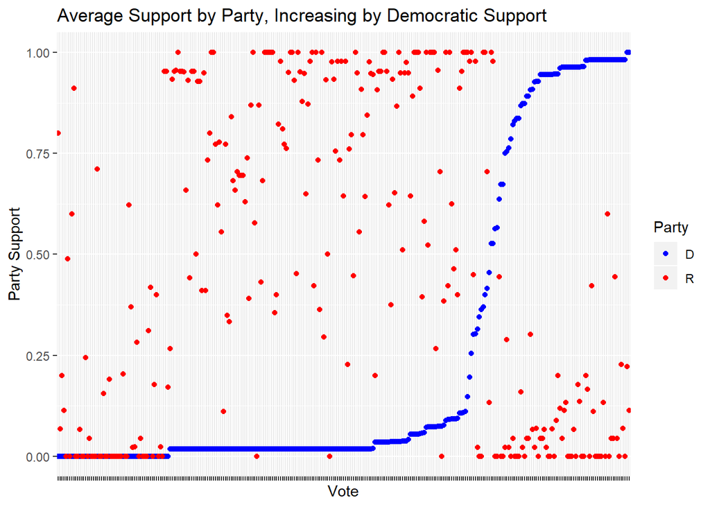

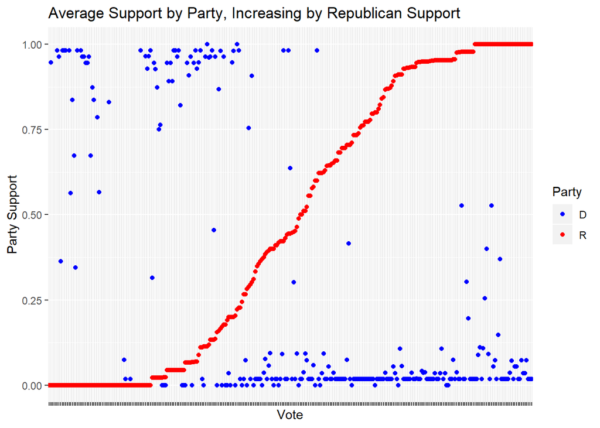

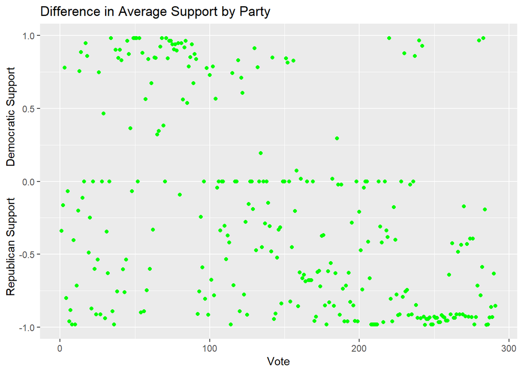

Notice that Democrats and Republicans usually vote differently.

## Average Supporty by Region

In addition to party, senators can be grouped into one of four regions based on their state: Northeast, South, Midwest, and West. As with the average party support, the average regional support of a bill can also be calculated by restricting to the senators in that region. Plotting shows the disparity in votes by region.

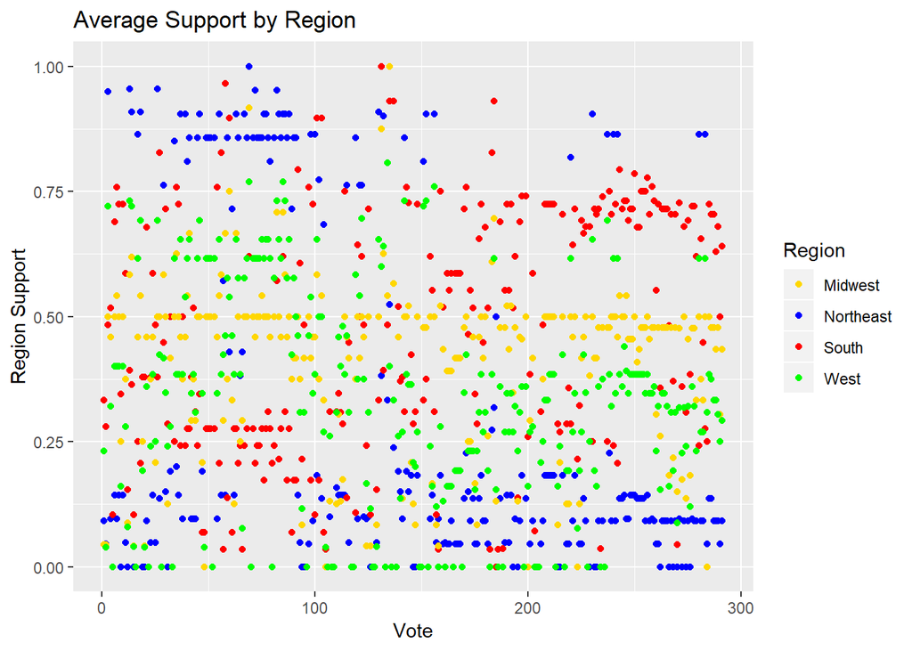

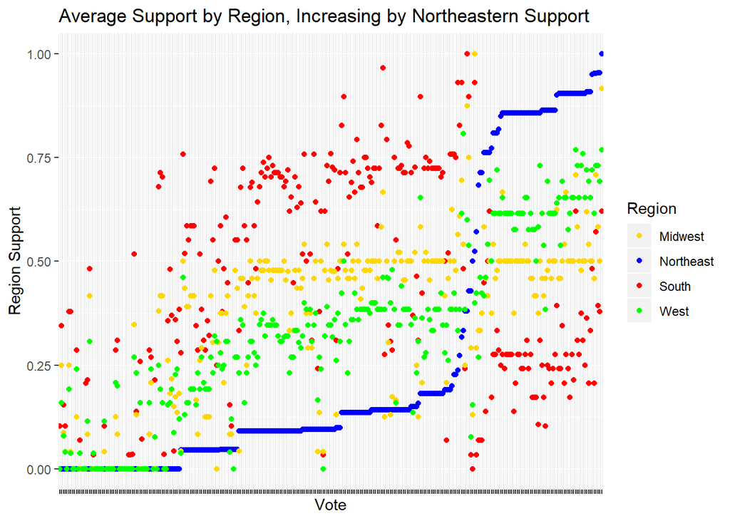

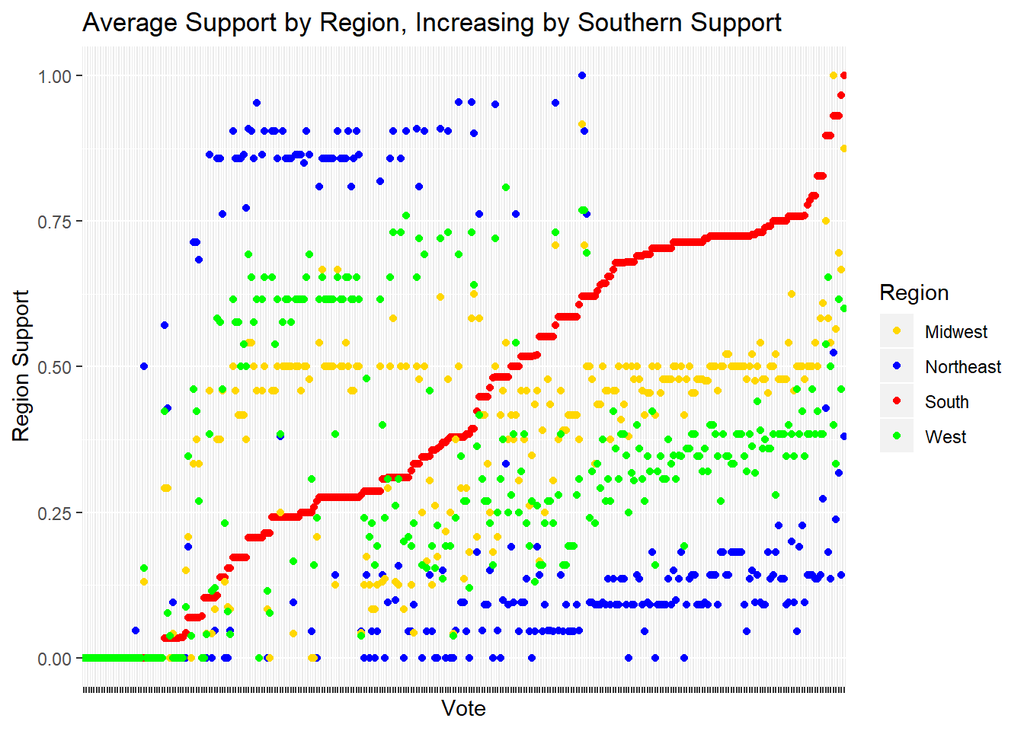

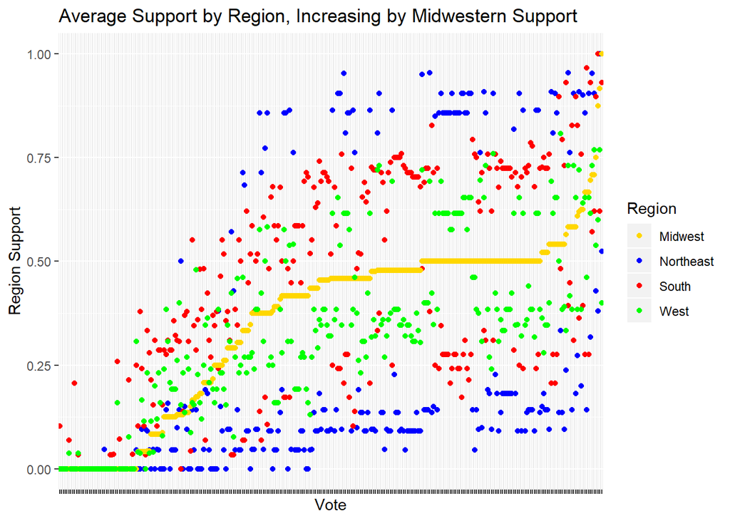

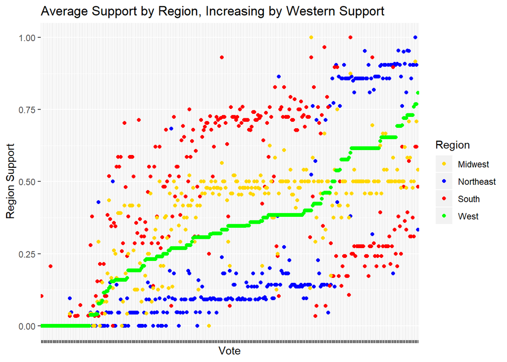

## Individual Senators Compared by Party and Region

We are also interested in viewing how consistently an individual senator votes with a given party or region. By considering the difference between an individual senator’s vote and the average vote, and taking a mean over all votes, we obtain a score between 0 and 1 for each senator with respect to each category. Organizing these results with a bar plot allows us to visualize how aligned each senator’s voting record is with the average voting record of the party or region.

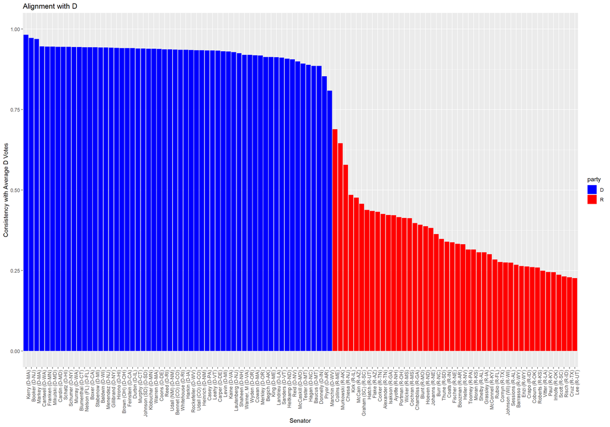

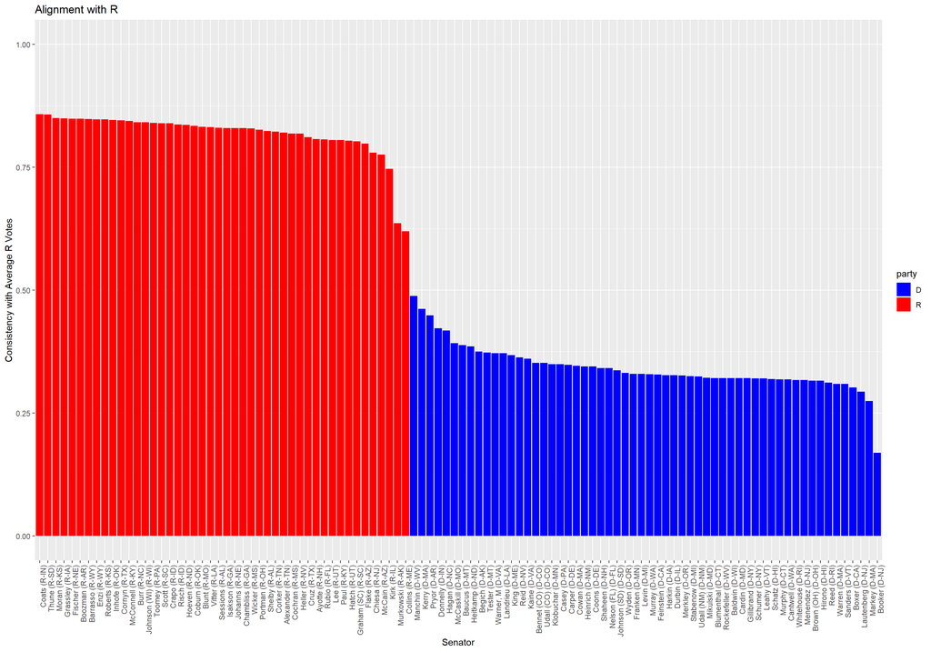

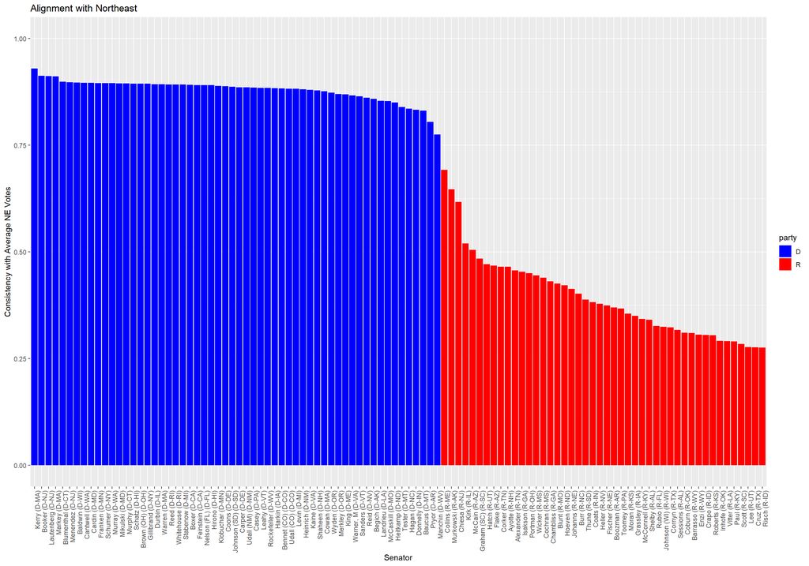

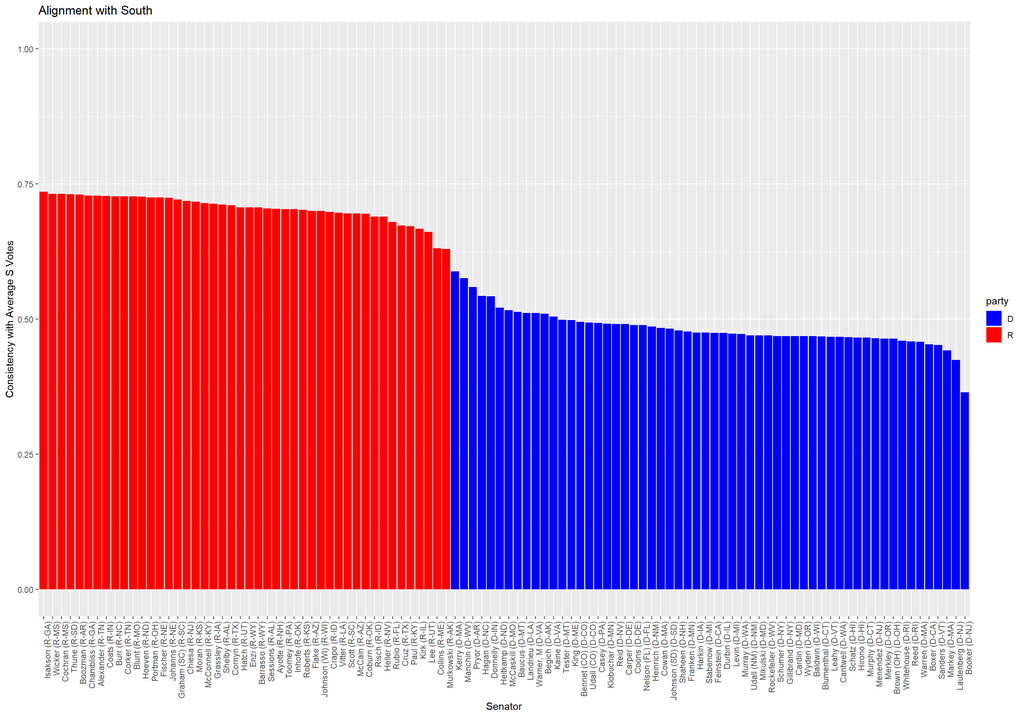

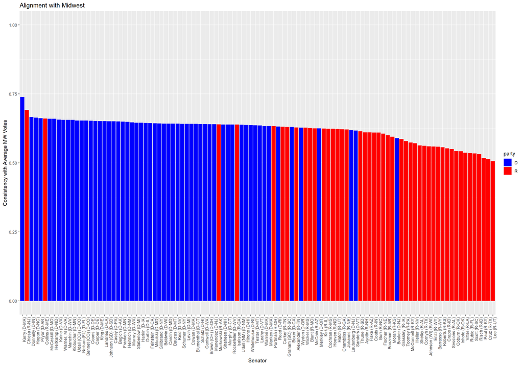

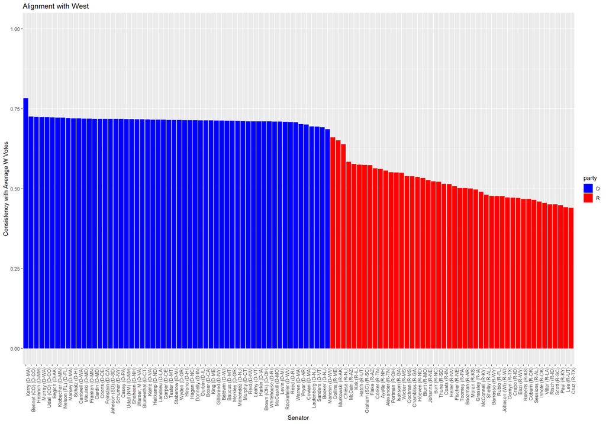

Notice that the average Northeast and West votes are primarily aligned with the average Democratic votes; likewise, Southern votes are primarily aligned wtih Republican votes. The Midwest exhibits more interesting behavior since it includes many senators of both parties.

## Regional Voting Consistency by Party

By comparing the average party support with the average regional support, we may view how aligned individual regions are with a given party. This is summarized by the bar chart below.

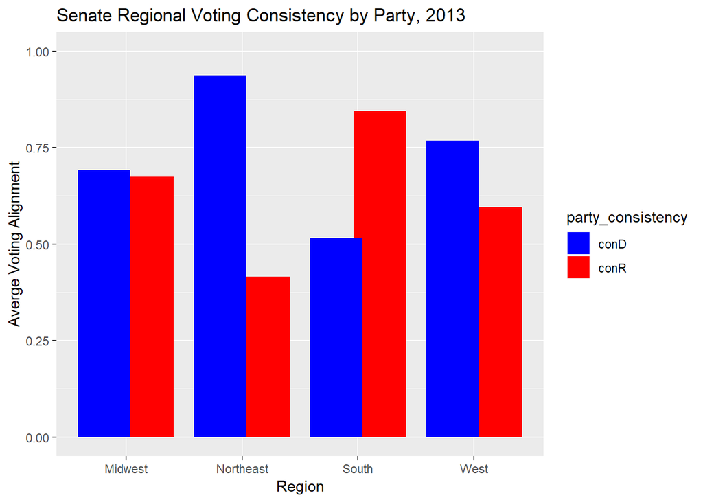